# Genotype simulation based on 1K Genome

Andrey Ziyatdinov

2017-07-31

# About

This is the first simulation in response to https://github.com/hemostat/jaccard/issues/2#.

## Original proposal for simulation

See Supplemental Material [link (pdf)](https://images.nature.com/full/nature-assets/nmeth/journal/v12/n8/extref/nmeth.3439-S1.pdf), Section 2.1. Genotype Simulation Strategy

> For the calibration and runtime experiments we used synthetic genotypes generated using a similar procedure as described in [27] based on the 1000 genomes project genotypes of European ancestry (populations: CEU, FIN, GBR, IBS, TSI). Briefly, each newly synthesized individual is assigned to A ancestors and the genotypes are built by first splitting the genome into blocks of 1000 SNPs and then randomly assigning each block to one of the ancestors and inheriting their SNPs. For lower numbers of ancestors the individuals tend to be more related. For example, A = 10 gives rise to almost unrelated individuals whereas A = 2 will result in substantial relatedness between some individuals

[27] Loh, P. R. et al. Efficient Bayesian mixed-model analysis increases association power in large cohorts. Nature genetics 47, 284–290 (2015).

Supplemental Material of Loh at al. 2015 [link(pdf)](https://images.nature.com/full/nature-assets/ng/journal/v47/n3/extref/ng.3190-S1.pdf), Section 5.1.1:

> In the simulations we used to benchmark computational costs, we simulated genotype data with N = 3,750 to 480,000 individuals and M = 150,000 or 300,000 SNPs by subsampling the desired number of SNPs from the WTCCC2 data set and then independently building N individuals as mosaics of individuals from the original data set using the following procedure. First, specify a number of “ancestors” A for each individual to have. Then, for each simulated individual, select A ancestors at random from among the original individuals and create the simulated individual’s genotype data by chopping the genome into segments of 1,000 SNPs and copying each segment from a randomly sampled (diploid) ancestor.

> Note that this approach retains realistic LD among SNPs, and for small values of A, it also retains population structure and introduces relatedness among individuals that share ancestors. In our simulations, we used A = 2 (substantial structure and relatedness) or A = 10 (low levels of structure and relatedness).

# Backgorund

## Include packages

```r
library(magrittr)
library(dplyr)

library(Matrix)
library(MASS)

library(pander)
```

```r
library(BEDMatrix)
library(pls)

library(bigmemory)

library(devtools)
load_all("~/git/variani/bigcov/")
```

```r
options(bigmemory.typecast.warning = FALSE)
```

## Local functions

```r
plot_pop <- function(mod, labs, labs_numeric = FALSE, ...)
{
  v1 <- mod$sdev[1]^2 / (sum(mod$sdev^2))
  v2 <- mod$sdev[2]^2 / (sum(mod$sdev^2))

  plot(mod$rotation[, 1], mod$rotation[, 2], type = "n",
    xlab = paste0("PC1 (", round(100*v1, 1), "%)"),
    ylab = paste0("PC2 (", round(100*v2, 1), "%)"),
    ...)

  if(labs_numeric) {
    text(mod$rotation[, 1], mod$rotation[, 2], label = as.numeric(labs), col = as.numeric(labs))
  } else {
    text(mod$rotation[, 1], mod$rotation[, 2], label = labs, col = as.numeric(labs))
  }
}
```

# PCA on orignial ancestry data

```r
dpath <- "~/Data/1KGenome/"
```

```r
f <- file.path(dpath, "phase3_common_EUR503_pruned_100ksubset_bed.bed")
bmat <- BEDMatrix(f)
```

```r
bdat <- bigdat(bmat, batch_size = 1e3)
```

```r
ids <- rownames(bmat)
ids <- strsplit(ids, "_") %>% sapply(function(x) x[1])

pop <- read.table(file.path(dpath, "pop_label_phase3_2504_without_rels"),
    header = TRUE, stringsAsFactors = FALSE) %>%
  mutate(pop = factor(pop)) %>%
  left_join(data_frame(sample = ids), ., by = "sample")
```

```r
grm <- bigdat_grm(bmat, batch_size = 1e5)
```

```r
mod <- prcomp(grm)
```

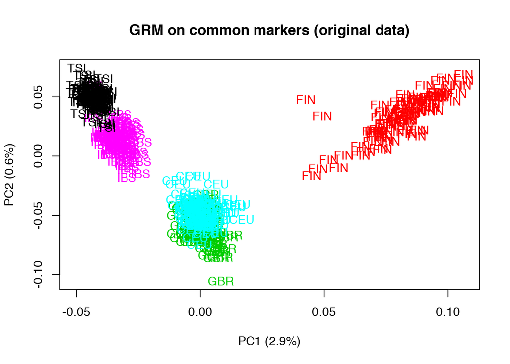

```r
plot_pop(mod, pop$pop, main = "GRM on common markers (original data)")
```

# Data simulation

```r
N_1k <- nrow(bmat)
```

## Functions

```r
get_acs_ind <- function(acs)
{
  sapply(sim_acs, function(x) sample(x$acs, 1))
}

get_acs_pop <- function(acs)
{
  sapply(sim_acs, function(x) x$acs %>%
    pop[["pop"]][.] %>% unique %>% sort %>% paste(collapse = "-"))
}
```

## Two ancesties (A = 2)

```r
A <- 2
N <- 6e2

set.seed(1)

sim_acs <- lapply(1:N, function(i) list(sample = i,
  acs = sample(seq(1, N_1k), A, replace = FALSE)))
```

```r
sdat <- big.matrix(nrow = N, ncol = ncol(bmat), type = "char")
```

```r
sdat <- big.matrix(nrow = N, ncol = ncol(bmat), type = "char")

num_batches <- bigdat_nbatch(bdat)
for(i in seq(1, num_batches)) {
  batch <- bdat$batches[i, ] %>% as.list
  cols <- seq(batch$beg, batch$end)
  rows <- seq(1, bigdat_nrow1(bdat))

  mat <- bigdat_slice(bdat, elem = batch$elem, rows = rows, cols = cols)

  rows_sim <- get_acs_ind(acs)
  mat_sim <- mat[rows_sim, ]

  sdat[, cols] <- mat_sim
}
```

```r
grm2 <- bigdat_grm(sdat, batch_size = 1e5)
```

```r
mod2 <- prcomp(grm2)
```

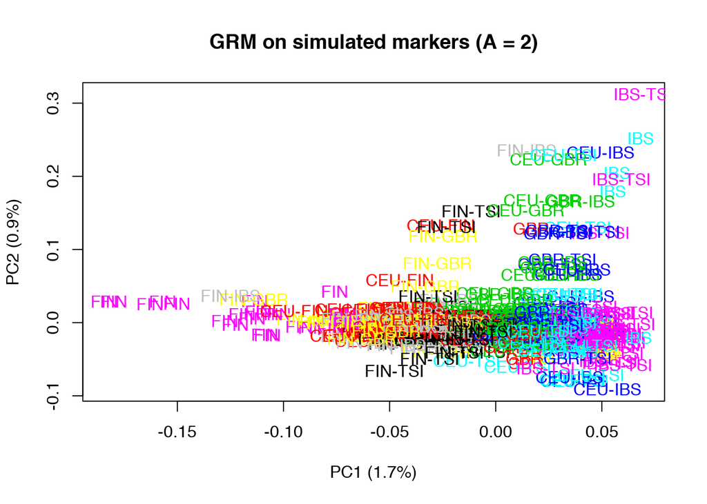

```r
labs <- get_acs_pop(sim_acs) %>% factor

plot_pop(mod2, labs, main = "GRM on simulated markers (A = 2)")
```

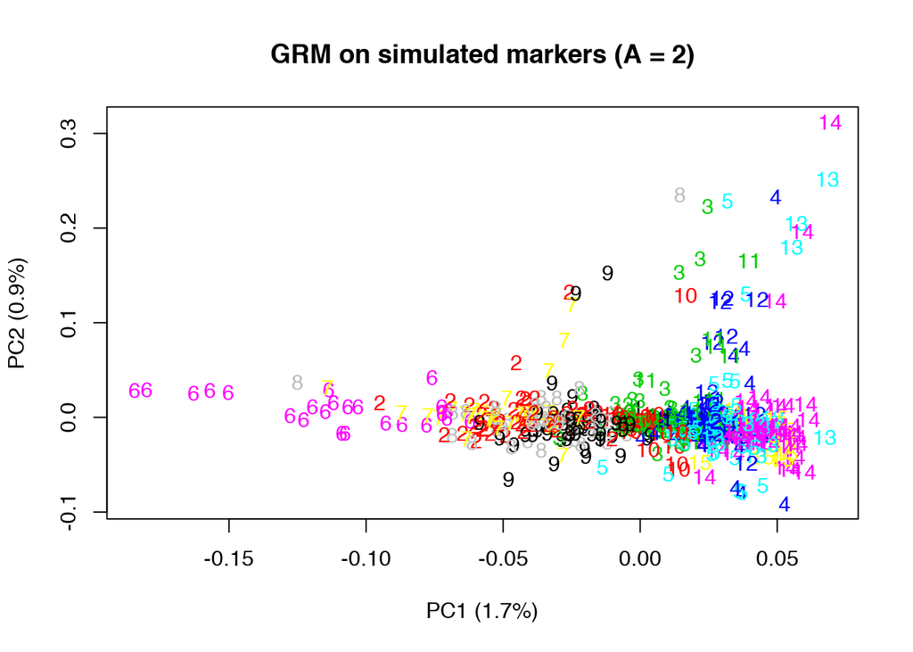

```r
plot_pop(mod2, labs, labs_numeric = TRUE, main = "GRM on simulated markers (A = 2)")
```

## Ten ancesties (A = 10)

```r
A <- 10
N <- 6e2

set.seed(1)

sim_acs <- lapply(1:N, function(i) list(sample = i,
  acs = sample(seq(1, N_1k), A, replace = FALSE)))
```

```r
sdat <- big.matrix(nrow = N, ncol = ncol(bmat), type = "char")
```

```r
sdat <- big.matrix(nrow = N, ncol = ncol(bmat), type = "char")

num_batches <- bigdat_nbatch(bdat)
for(i in seq(1, num_batches)) {
  batch <- bdat$batches[i, ] %>% as.list
  cols <- seq(batch$beg, batch$end)
  rows <- seq(1, bigdat_nrow1(bdat))

  mat <- bigdat_slice(bdat, elem = batch$elem, rows = rows, cols = cols)

  rows_sim <- get_acs_ind(acs)
  mat_sim <- mat[rows_sim, ]

  sdat[, cols] <- mat_sim
}
```

```r
grm3 <- bigdat_grm(sdat, batch_size = 1e5)
```

```r
mod3 <- prcomp(grm3)
```

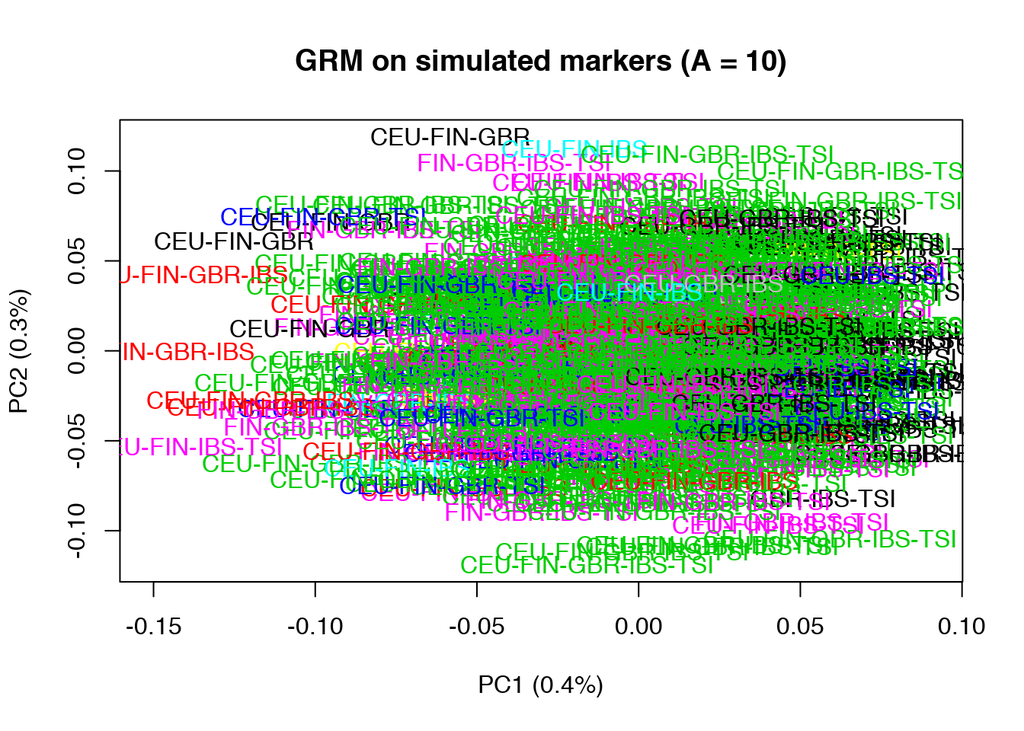

```r
labs <- get_acs_pop(sim_acs) %>% factor

plot_pop(mod3, labs, main = "GRM on simulated markers (A = 10)")
```

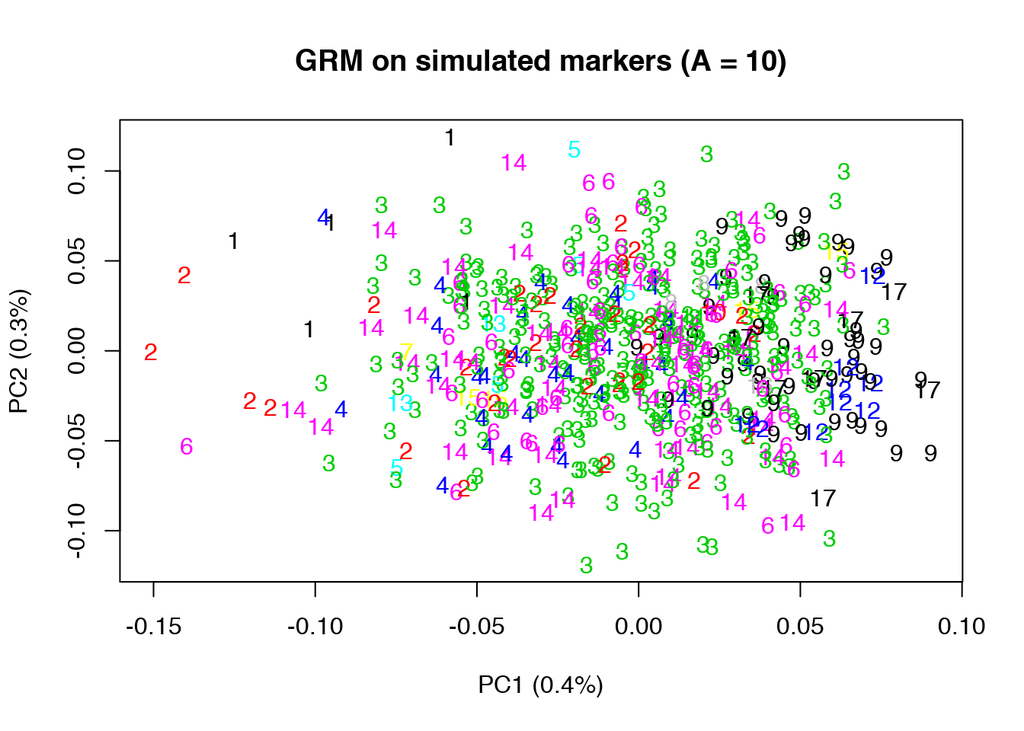

```r
plot_pop(mod3, labs, main = "GRM on simulated markers (A = 10)", labs_numeric = TRUE)
```